# Plotting Roman Roads

#### Cities with Populations

Cities from ORBIS with associated population estimates are in another file (https://doi.org/10.1371/journal.pone.0208744.s008)

```r
# ancient Roman cities with population estimates
s008 <- read.csv("https://raw.githubusercontent.com/sdam-au/R_code/master/data/s008.txt")
```

Look at some entries:

```r
head(s008)
```

```
  objectid    label XCOORD YCOORD                  PLPATH rank popest
1    50327     Roma 41.892 12.486     /places/423025/roma  100  1e+06
2    50294 Patavium  45.41 11.877 /places/393473/patavium   90  3e+04
3    50330 Rutupiae 51.294  1.332  /places/79664/rutupiae   70  7e+03
4    50008   Aelana 29.664 34.974   /places/746700/aelana   80  1e+04
5    50326   Regium 38.109 15.644  /places/452416/rhegion   80  8e+03
6    50329 Rusicade 36.883  6.906 /places/305137/rusicade   80  1e+04
```

where the last column has some city’s population.

However not all cities are covered in file `s008`.

```r
head(match(as.numeric(dimnames(net)[[1]]), s008$objectid), 20)
```

```
 [1]  NA  NA  NA  NA  NA  NA  NA   4  NA  37  91  24  NA  86  NA  NA  83  90  87 236
```

```r
# second column has city names
lbs0 <- as.vector(s008[match(as.numeric(dimnames(net)[[1]]), s008$objectid),2])
```

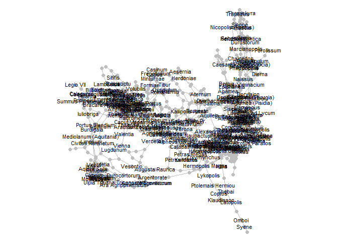

Graph with large Roman cities and road network

```r
# force directed layout with customized node labels
multigraph(net*100, directed=FALSE, layout="force", seed=1, scope=scp, lbs=lbs0)
```

In principle, the population size can be reflected in the graph of the network

```r
# seventh column has population estimates
popl <- as.vector(s008[match(as.numeric(dimnames(net)[[1]]), s008$objectid),7])
```

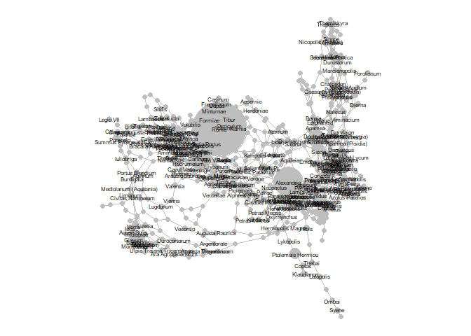

Graph with large Roman cities and road network (customized)

```r
# force directed layout with customized node size and labels
multigraph(net*100, directed=FALSE, layout="force", seed=1, scope=scp, lbs=lbs0, cex=popl)
```

#### Coordinates

```r
# coordinates are the third and fourth columns
cds <- as.vector(s006[match(as.numeric(dimnames(net)[[1]]), s006$objectid), 3:4])
```

However, there are three duplicate labels in `s006`.

```r
# city names are in the ssecond column
rownames(cds) <- as.vector(s006[match(as.numeric(dimnames(net)[[1]]), s006$objectid), 2])
```

```
#Error in `.rowNamesDF<-`(x, value = value) :
#  duplicate 'row.names' are not allowed
#In addition: Warning message:
#non-unique values when setting 'row.names': ‘Isca’, ‘Noviomagus’, ‘Venta’
```

## Maritime routes

### See also

- [Plotting Roman Empire transport network](https://sdam-au.github.io/sdam/articles/TransportNetwork.html)
- [Plotting ancient Roman provinces and regions](https://sdam-au.github.io/sdam/articles/RomanProvs.html)
- [Re-encoding Greek characters from ‘EDH’ dataset](https://sdam-au.github.io/sdam/articles/Encoding.html)
- [`"sdam"` manual](https://github.com/mplex/cedhar/blob/master/typesetting/reports/sdam.pdf)
- [Social Dynamics and complexity in the Ancient Mediterranean Project](https://sdam-au.github.io/sdam-au/)